# Jokes Recommendation

Columbia University IEOR 4571 - Personalization Theory and Applications

Gaurav Singh, Carolyn Silverman, Cindy Wu, Maura Fitzerald

01 November 2017

## Evaluation

- Item-based collaborative filtering with Pearson correlation
- Item-based collaborative filtering with cosine similarity
- User-based collaborative filtering with Pearson correlation
- User-based collaborative filtering with cosine similarity
- SVD for Matrix Factorization
- A random model (baseline)

Finally, we evaluate the overall accuracy of the models, as functions of the following variables:

- proportion of the dataset we train on
- number of ratings given per user in the test set

The following sections will elaborate on each of these tasks and display the results.

### Cross Validation

We start by limiting the dataset to the first 10,000 users to make training all of the models more manageable. Then, we split the ratings data into a training set and a test set based on users. For our initial evaulations, we will train on 80% of users and test our models on the other 20%.

```r
ratings <- ratings[1:10000,]
set.seed(666)
train_proportion = 0.8
split <- train_test_split(ratings, train_proportion = train_proportion)
train_data <- split$train_data
training_sparse <- as(as.matrix(train_data), 'realRatingMatrix')
```

Next, we devise an evaluation scheme on the training set to select the best models and tune parameters. We will use the evaluationScheme function in the recommenderlab package. We assign initial values (or a range of values to test) to the following parameters:

- n_fold: Number of cross validation folds
- items_to_keep: number of items given for test users; the rest are withheld for evauation
- threshold: jokes with a rating higher than this threshhold will be considered a positive rating in the binary representation
- n_recommendations: number of recommendations for the top-n lists
- k_items: hyperparameter for item-based cf (neighborhood size)
- nn_users: hyperparameter for user-based cf (neighborhood size)

```r
n_fold <- 5
items_to_keep <- 15
rating_threshold <- 5
n_recommendations <- c(1, 3, 5, seq(10, 40, 10))
k_items <- c(5,seq(10, 40, 10))
nn_users <- c(5, 10, 25, 100, 250)
k_svd <- c() #possible values for k in svd
eval_sets <- evaluationScheme(data = training_sparse, method = "cross-validation",
                  k = n_fold, given = items_to_keep, goodRating = rating_threshold)
```

```r
models_to_evaluate <- list(
  IBCF_cos = list(name = "IBCF", param = list(method = "cosine")),
  IBCF_cor = list(name = "IBCF", param = list(method = "pearson")),
  UBCF_cos = list(name = "UBCF", param = list(method = "cosine")),
  UBCF_cor = list(name = "UBCF", param = list(method = "pearson")),
  random = list(name = "RANDOM", param=NULL)
)
list_results <- evaluate(x = eval_sets, method = models_to_evaluate, type="topNList", n = n_recommendations)
rat_results <- evaluate(x = eval_sets, method = models_to_evaluate, type="ratings")
err <- do.call(rbind.data.frame, avg(rat_results))
```

First, we evaluate top-N lists for each model:

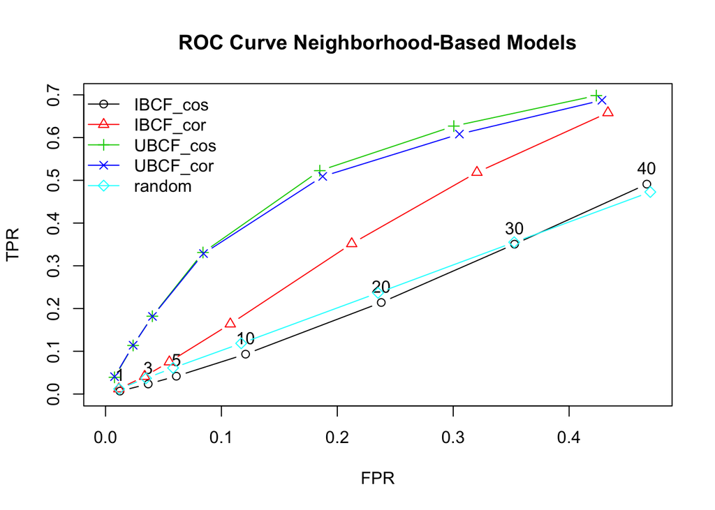

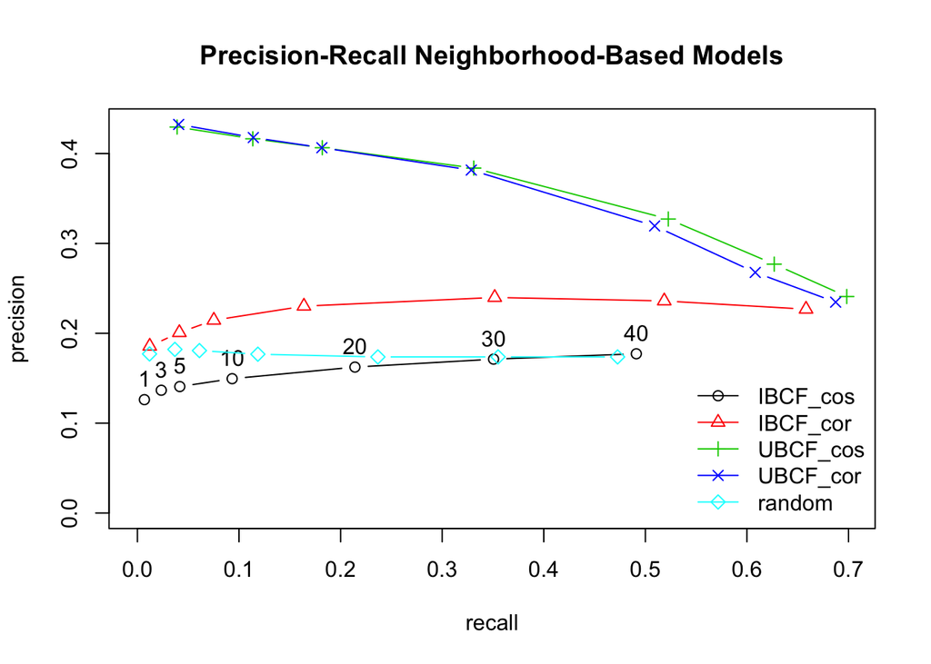

```r
plot(list_results, annotate = 1, legend = "topleft")
title("ROC Curve Neighborhood-Based Models")
plot(list_results, "prec/rec", annotate = 1, legend = "bottomright")
title("Precision-Recall Neighborhood-Based Models")
```

Next, we compare error metrics for the ratings.

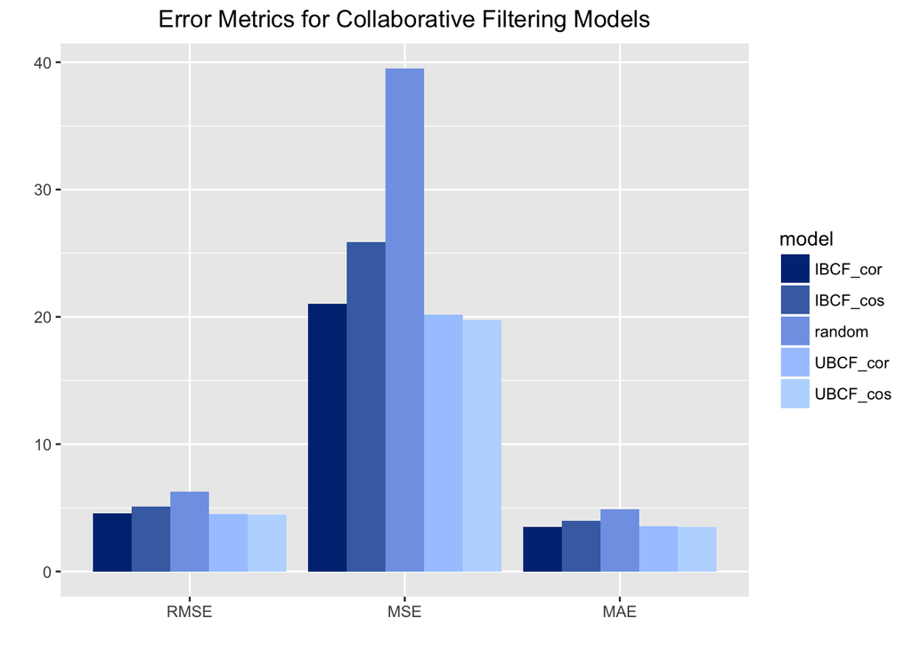

```r
err$model <- row.names(err)
err_melted <- melt(err, id.vars = "model")
ggplot(err_melted, aes(variable, value)) +
  geom_bar(aes(fill=model), position = "dodge", stat="identity") +
  scale_fill_manual(values=pal(length(models_to_evaluate))) +
  ggtitle("Error Metrics for Collaborative Filtering Models") +
  ylab("") + xlab("") + theme(plot.title = element_text(hjust = 0.5))
```

The results indicate that user-based collaborative filtering with cosine similarity performs best on the jester dataset. For the item-based approaches, Pearson correlation outperforms cosine similarity. Let’s now use cross-validation to tune the hyperparameter for each of these models.

```r
models_to_evaluate_ib <- lapply(k_items, function(k){
  list(name = "IBCF", param = list(method = "pearson", k = k))
})
names(models_to_evaluate_ib) <- paste0("IBCF_k_", k_items)
list_results_ib <- evaluate(x = eval_sets, method = models_to_evaluate_ib, n = n_recommendations)
avg_matrices_ib <- lapply(list_results_ib, avg)
rat_results_ib <- evaluate(x = eval_sets, method = models_to_evaluate_ib, type="ratings")
err_ib <- do.call(rbind.data.frame, avg(rat_results_ib))
```

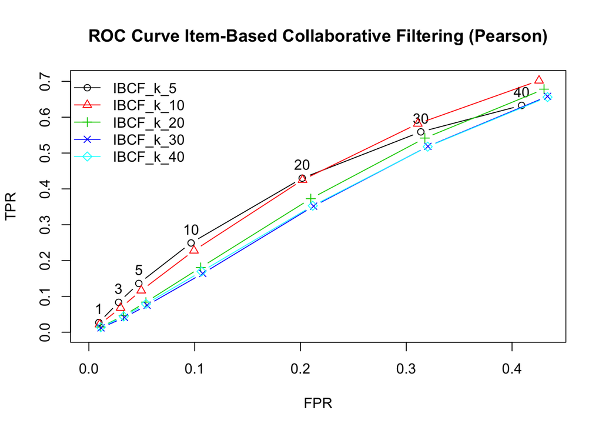

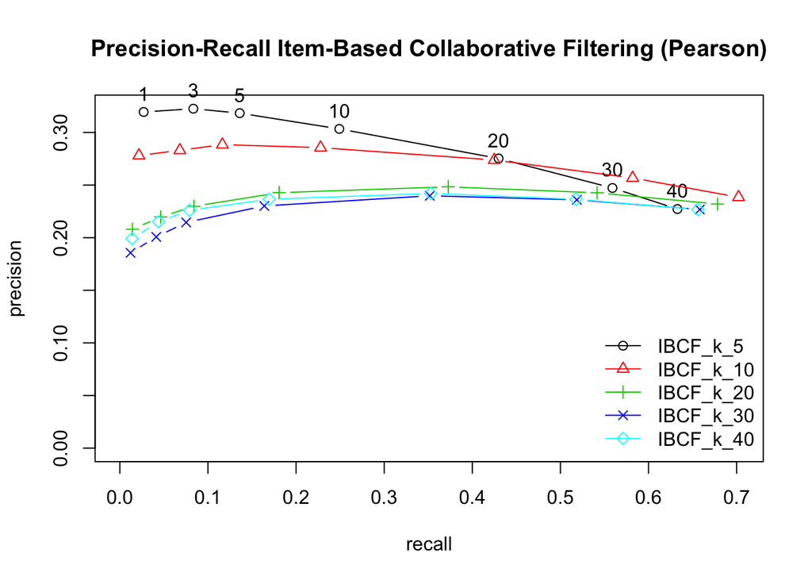

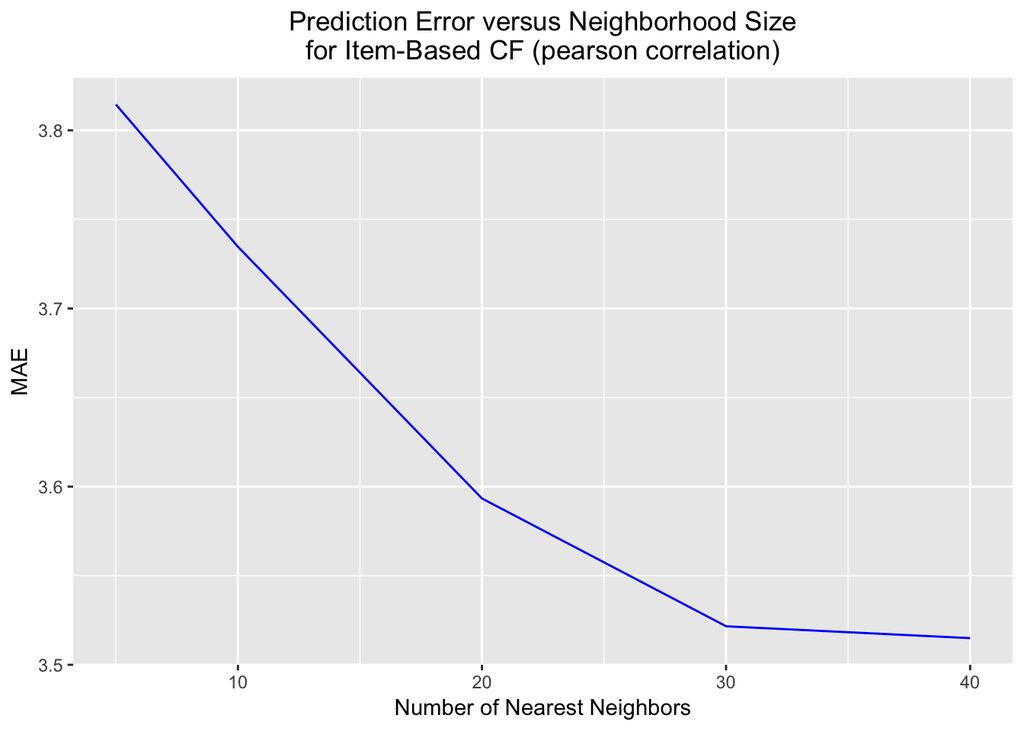

```r
plot(list_results_ib, annotate = 1, legend = "topleft")
title("ROC Curve Item-Based Collaborative Filtering (Pearson)")
plot(list_results_ib, "prec/rec", annotate = 1, legend = "bottomright")
title("Precision-Recall Item-Based Collaborative Filtering (Pearson)")
err_ib$k <- k_items
ggplot(err_ib, aes(x = k, y = MAE)) + geom_line(color = "blue") +
  ggtitle("Prediction Error versus Neighborhood Size\nfor Item-Based CF (pearson correlation)") +
  theme(plot.title = element_text(hjust = 0.5)) +
  xlab("Number of Nearest Neighbors")
```

The optimal k for item-based CF is 5 or 10 when we want to predict top-N lists. However, if we want to predict the ratings, a higher value of k is better. The plot of MAE versus neighborhood size starts to level off after k=30, so we will use k=30 as the neighborhood size for our Pearson item-based CF model when we want to predict ratings.